# Direct Inclusion in Municipal Decision-Making

Evidence from a field experiment in Lebanon

Macartan Humphreys

WZB / EGAP

[figure not shown]

[figure not shown]

[figure not shown]

[figure not shown]

Lara Azzam, Nora Chirikure, and Rana Habr, Macartan Humphreys

# 1. Intro

Does simple direct inclusion in *municipal* decision-making affect trust and behavior towards the municipality?

## Headline

- Design: Individual level random assignment to take part in extended municipality decision making
- Design based inference: trust index null. Allocation to the municipality rises.
- Mixed methods: Qualitative and quantitative analyses agree on the major moving parts of the model. They disagree on *why* effects are weak.

2. Design · 3. Inference · 4. Mixed methods · 5. Takeaways

# 2. Design

Two-arm trial in 23 municipalities. Each municipality has three 15-member task forces.

## Design

- Recruited from baseline, **conditional on interest**
- Task force: 10 appointed members (board, experts, community leaders) plus 5 randomly selected residents
- Control: interested residents who were not assigned

Invitation is random among those who said they wanted to come. Effects are for that willing set. The LATE is for those who attend at least two meetings.

Scheme · Timeline · Attendance · Who attended · Context

## Scheme

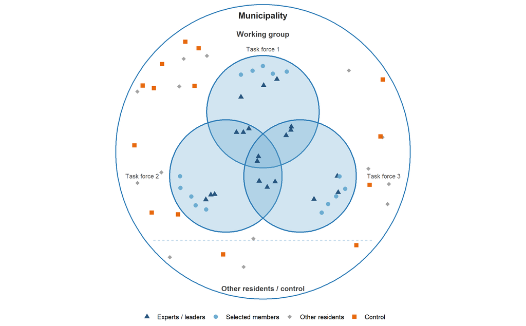

## Timeline

Implementation ran over roughly two years in 23 municipalities.

Context · Attendance

## Interest

Stated interest is roughly bimodal. 28 percent say they are definitely not interested; 30 percent say they certainly are.

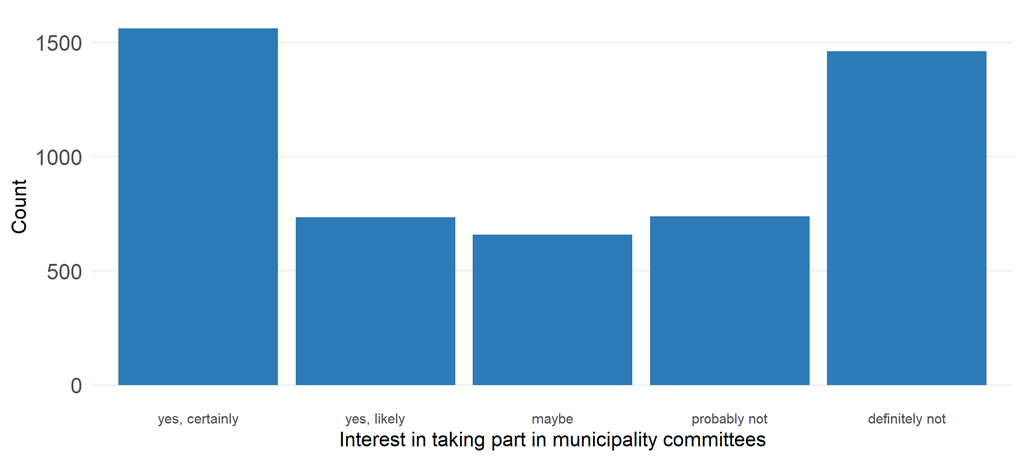

| Interest | Female | Age | Corruption | Allocation | N |
| --- | --- | --- | --- | --- | --- |
| yes, certainly | 0.46 | 44.48 | 0.28 | 0.16 | 1562 |
| yes, likely | 0.46 | 44.32 | 0.28 | 0.14 | 735 |
| maybe | 0.43 | 46.21 | 0.29 | 0.08 | 658 |
| probably not | 0.49 | 46.31 | 0.26 | 0.15 | 738 |
| definitely not | 0.56 | 46.44 | 0.23 | 0.12 | 1462 |

- Willing set somewhat more **male** and somewhat **younger** ($p < 0.01$; age $p < 0.01$)
- Those claiming corruption marginally *more* likely to volunteer ($p < 0.05$)
- Those providing a larger allocation more likely to volunteer ($p < 0.01$)
- Differences are not huge

## Actual attendance

28 percent of baseline respondents say they do not want to take part. Among those invited, 37 percent attend no meetings. 43 percent attend at least two.

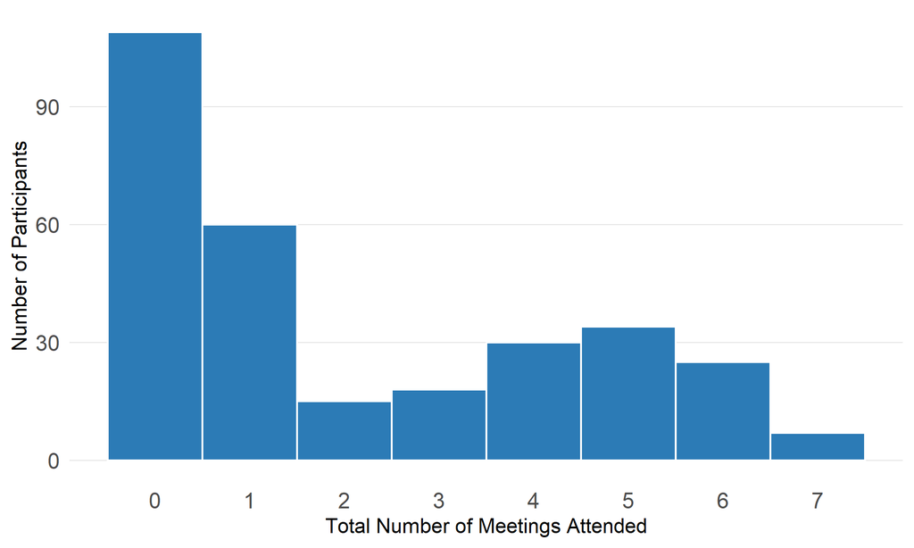

Attendance among randomly assigned participants was low. People had other things going on. Context

# 3. Design-based inference

Attitudes: survey trust index. Behavior: real allocation to the municipality.

## Trust index

No movement on stated trust. The ITT is $0.01$ (95 percent CI $-0.09$ to $0.12$).

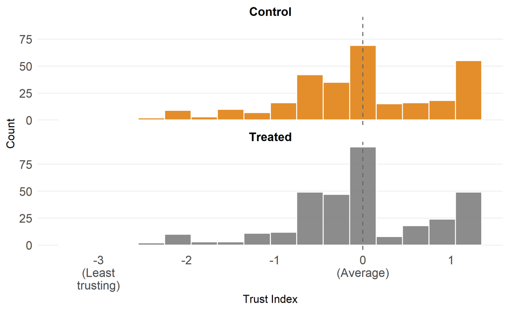

We can reject average effects of invitation larger than about $0.12$ of a standard deviation. Allocation · Index items

## Allocation

Treatment raises the share who allocate any real funds to the municipality by 10 percentage points (control mean 67 percent; $p < 0.01$).

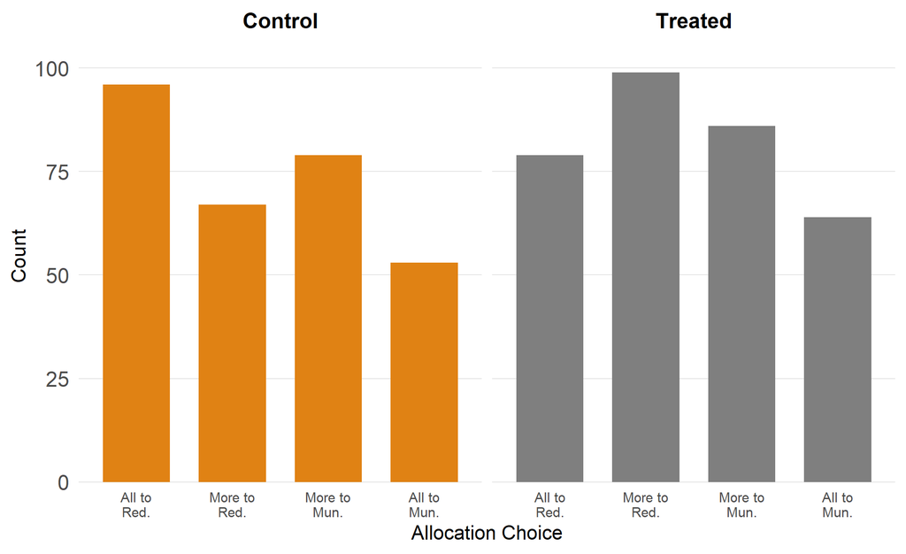

Amount ITT $+65,277$ LBP ($p < 0.05$). LATE among those attending at least two meetings: $+162,399$ LBP. Estimated effects · ITT · LATE

## Estimated effects

ITT and LATE on allocation: Amount, More, and Some. Subgroup intervals are wide. No statistically significant heterogeneity by gender or local marginalization.

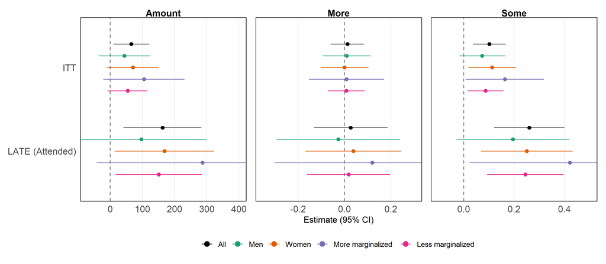

ITT · LATE · Trust items

## Primary results: ITT

ITT: behavioral outcomes

|  | Amount | More | Some |
| --- | --- | --- | --- |
| treated | 65.28* | 0.01 | 0.10** |
|  | (28.41) | (0.04) | (0.03) |
| Control mean | 553.20 | 0.444 | 0.670 |
| R<sup>2</sup> | 0.26 | 0.23 | 0.24 |
| Adj. R<sup>2</sup> | 0.23 | 0.20 | 0.21 |
| Num. obs. | 618 | 618 | 618 |
| RMSE | 490.35 | 0.63 | 0.57 |

***p < 0.001; **p < 0.01; *p < 0.05. All models include municipal fixed effects and inverse-probability weights. Amount is in thousands of LBP.

LATE · Estimated effects

## Primary results: LATE

LATE: behavioral outcomes

|  | Amount | More | Some |
| --- | --- | --- | --- |
| attended | 162.40** | 0.03 | 0.26*** |
|  | (61.85) | (0.08) | (0.07) |
| Control mean | 553.20 | 0.444 | 0.670 |
| R<sup>2</sup> | 0.26 | 0.24 | 0.24 |
| Adj. R<sup>2</sup> | 0.23 | 0.20 | 0.21 |
| Num. obs. | 529 | 529 | 529 |
| RMSE | 491.95 | 0.63 | 0.57 |

***p < 0.001; **p < 0.01; *p < 0.05. IV robust models. All models include municipal fixed effects and inverse-probability weights. Amount is in thousands of LBP.

ITT · Estimated effects

# 4. Qual and mixed methods

They agree on the major moving parts of the model. They disagree on what the invitation did.

## Working graph

The graph represents a **mid-level theory**.

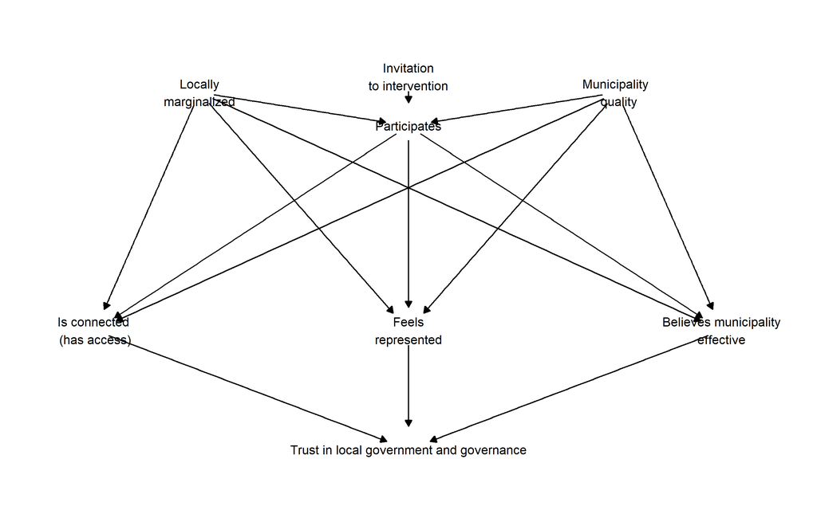

No leftover path from invitation or participation into trust. Paths run through inclusion, understanding, and connections. Full theory DAG

## Completing types

The working graph implies a large type space. The unrestricted binary model has 8,796,093,022,208 types ($2^{43}$). Count

We restrict: an individual’s effect may be positive, negative, or flat, but may not change sign across backgrounds. A three-parent node then has 104 types rather than 256.

Interviews supply two things the survey does not:

1. A factual parent–child pair (scores cut at 0.5)
2. A single-parent attribution (the 4-by-2 uses cutoff 0.75)

Cells that would require flipping two or more parents are not elicited. The unit’s count is split across the remaining types. The survey has levels only.

## Raw scores

Each arrow is a 4-by-2: factual pair by whether the coder attributed a difference.

Invitation $\rightarrow$ participation: 1 positive, 2 negative, 43 none. Hard four-type counts: 21 chronic, 22 destined, 2 adverse, 1 beneficial.

| Factual (invitation → participation) | Attributed | Not attributed |
| --- | --- | --- |
| 0 → 0 | 1 | 4 |
| 0 → 1 | 1 | 5 |
| 1 → 0 | 1 | 17 |
| 1 → 1 | 0 | 17 |

Most invited participants do not attribute participation to the invitation. All arrows · Quotes · 4-by-2 note

## Quotes: $n_{+}$, $n_{-}$, $n_{0}$

Curated excerpts from the paper quote table. One excerpt per sign where one exists. No unit identifiers.

| Arrow | *n*<sub>+</sub> | *n*<sub>−</sub> | *n*<sub>0</sub> | Examples |
| --- | --- | --- | --- | --- |
| Invitation → Participation | 1 | 2 | 43 | **[0]** *A subject who was invited and participated said:* "I was in the running in the elections and didn't win, but regardless, I always participate and am active socially and I am always ready to h… |
| Marginalization → Participation | 5 | 4 | 37 |  |
| Municipality → Participation | 4 | 3 | 39 | **[+]** *A subject who rated the municipality low and did not participate said:* "If the municipality encourages us to start groups or local women ngos and work for the betterment of the village, it w… |
| Marginalization → Connections | 5 | 13 | 28 | **[0]** *A subject who was not marginalized and had high connections said:* "We're a small town from the same religion and sect, so everyone knows everyone" |
| Municipality → Connections | 5 | 1 | 40 | **[0]** *Interviewer's notes about a person who rated the municipality high and had high connections:* His connectedness is not linked to efficiency rather to his position and personal relations to th… |
| Participation → Connections | 8 | 1 | 37 | **[+]** *Interviewer's notes about a person who participated and had high connections:* Respondent participates often and feels connected, if she participated less, she'll probably be less connected. … |
| Marginalization → Inclusion | 4 | 13 | 29 |  |
| Municipality → Inclusion | 7 | 9 | 30 |  |
| Participation → Inclusion | 3 | 1 | 42 |  |
| Marginalization → Understanding | 4 | 8 | 34 | **[−]** *Interviewer's notes about a person who was not marginalized and had high understanding:* They are generally not marginalized from the municipality, but seem in disalignment with the current m… |
| Municipality → Understanding | 13 | 10 | 23 | **[+]** *A subject who rated the municipality low and had low understanding said:* "We have all the needs you can think of and the municipality doesn't and cannot do anything: it doesn't have the reso… |
| Participation → Understanding | 1 | 0 | 45 | **[+]** *A subject who participated and had high understanding said:* "People criticize the municipality because they don't know, I told the mayor we need to have monthly meetings, let them speak, and… |
| Connections → Trust | 11 | 0 | 35 | **[0]** *Interviewer's notes about a person who had high connections and had low trust:* Respondent stated that for him, this intervention was not about understanding municipalities and municipal proc… |
| Inclusion → Trust | 16 | 3 | 27 |  |
| Understanding → Trust | 15 | 8 | 23 | **[0]** *Interviewer's notes about a person who had high understanding and had high trust:* It's unclear if the high level of trust is linked to efficiency or political/family alignment |

All arrows · Raw scores

## Interview DAG

Parent-effect means from the interviews. Blue positive, red negative. Thickness is $|$parent effect$|$. The number beside a node is the share coded 1.

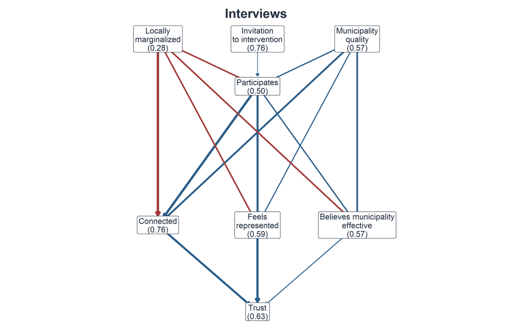

Survey DAG · XY plot

## Survey DAG

Same layout, scale, and colors. Survey parent-effect means.

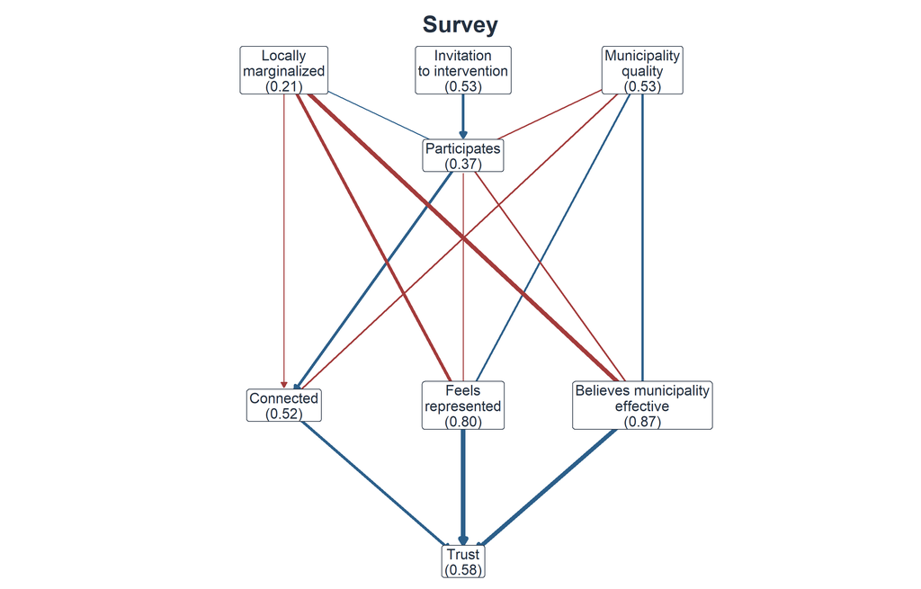

Interview DAG · Where they agree

## Invitation to trust

Query mean, with query standard deviation in parentheses. The columns are not four posteriors from the same model.

| Estimand | Priors | Interviews | Survey | Mixed |
| --- | --- | --- | --- | --- |
| Average effect of invitation on trust | -0.0000 (0.0002) | 0.0001 (0.0003) | 0.0000 (0.0001) | 0.0000 (0.0001) |
| Estimated share for whom invitation raises trust | 0.058 (0.006) | 0.048 (0.004) | 0.059 (0.002) | 0.058 (0.002) |
| Estimated share for whom invitation caused trust, among invited people who trust | 0.116 (0.012) | 0.102 (0.008) | 0.110 (0.004) | 0.109 (0.005) |
| Natural indirect effect of invitation on trust through inclusion | -0.0000 (0.0001) | -0.0000 (0.0002) | -0.0000 (0.0001) | -0.0000 (0.0001) |
| Natural indirect effect of invitation on trust through understanding | 0.0000 (0.0001) | -0.0000 (0.0001) | -0.0000 (0.0001) | -0.0000 (0.0001) |
| Natural indirect effect of invitation on trust through connections | -0.0000 (0.0001) | -0.0000 (0.0001) | 0.0000 (0.0000) | 0.0000 (0.0000) |

**Note**

The long chain produces a **tight prior on small treatment effects**. Many hoops. Mass on 01/10 for Invitation $\rightarrow$ Trust is rare even under Dirichlet(1). Types still update on short arrows. The ATE stays near zero unless a completing path exists. The interview, survey, and mixed columns **replace the alphas**. They are not the prior shrinking the data.

Share rows · Validation

## Agree and disagree

They agree on the major moving parts.

- Inclusion, understanding, and connections raise trust on both sides
- Marginalization lowers connections and inclusion
- Participation raises connections (0.062 interviews; 0.039 survey)

They disagree on what the treatment did.

- Invitation $\rightarrow$ participation is small on both sides and weaker in the interviews (0.007 vs 0.035)
- Participation $\rightarrow$ inclusion and participation $\rightarrow$ understanding are positive in the interviews and approximately zero or slightly negative in the survey

The invitation-to-trust average is approximately zero on every column. The experimental allocation ITT is not on this graph.

## Validation

26 of 46 interviews link to the survey. Small $n$. Invitation agrees on 23 of 26 (0.88). Other nodes agree on about 0.65. Omnibus $p = 0.028$.

| Node | *n* | Agree | ρ01 | p01 | ρ4 | p4 |
| --- | --- | --- | --- | --- | --- | --- |
| Invitation to intervention | 26 | 0.88 | 0.75 | <0.001 | 0.75 | <0.001 |
| Locally marginalized | 25 | 0.64 | 0.13 | 0.544 | --- | --- |
| Municipality quality | 25 | 0.68 | 0.36 | 0.078 | 0.37 | 0.072 |
| Participates | 26 | 0.62 | 0.23 | 0.257 | 0.40 | 0.044 |
| Is connected (has access) | 23 | 0.65 | 0.19 | 0.386 | 0.42 | 0.049 |
| Feels represented | 25 | 0.68 | 0.42 | 0.038 | 0.25 | 0.233 |
| Believes municipality effective | 26 | 0.65 | 0.34 | 0.092 | 0.36 | 0.072 |
| Trust in local government | 26 | 0.65 | 0.28 | 0.161 | 0.36 | 0.075 |

Correlations are far from unity. No unit identifiers. Queries

# 5. Takeaways and questions

Several take-aways follow.

## Takeaways

- Demand for participation is low. 28 percent say they do not want to take part. Among those invited, 57 percent do not attend regularly.
- The trust index does not move. The allocation does, mainly at the low end.
- Qual and quant agree on the major moving parts. They disagree on what the invitation did.
- The working graph has no leftover path from invitation into a final outcome. It cannot speak to the experimental contrast as currently drawn.
- If a municipality already plans to include people, tihs is good news. But it does not provide grounds to set up or orient programs towards this goal.

Questions

## Questions

1. Why did the allocation move, and mainly at the low end, while the trust index did not?
2. Are the two outcomes different objects, or is one just noisier? Linked-interview correlations sit around 0.3. Is that enough to treat the nodes as the same?
3. The working graph has one trust node and no leftover path from invitation. What graph would let the mixed-methods analysis speak to the experimental contrast?
4. Invitation barely moves participation in the interviews. Is that a first-stage failure, or a mismatch among three participation measures: LATE attendance of at least two meetings, the survey civic composite, and the interview coder score?
5. The 4-by-2 at 0.75 is weakly negative. The parent-effect query is weakly positive. Which object should update beliefs about invitation?

Back to headline · Extras

# Extra

Material off the main path. Each slide links back.

- Context · Trust items
- Full theory DAG · All arrows
- XY plot · 4-by-2 note
- Type count · Share rows · Node means

Return to headline

## Context

Implementation ran through conflict, displacement, and the first municipal elections in nearly a decade (May 2025).

- Tensions from October 2023. War September–November 2024, and again from March 2026.
- Working groups suspended in September 2024 and resumed in early 2025.
- Some activities adapted (for example psychosocial support online).
- Newly elected officials sometimes shifted priorities away from earlier working-group lists.

Attendance was low. People had other things going on.

Back to design · Timeline · Attendance

## Trust-index items

ITT and LATE on the index and its three items. Subgroup intervals are wide.

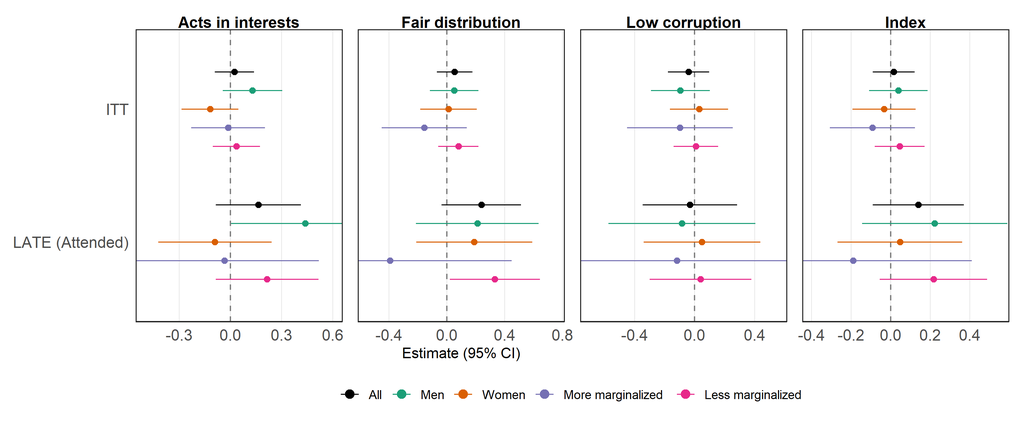

Back to trust · Estimated effects

## Full theory DAG

Project interruptions are on this graph. Queries drop that node.

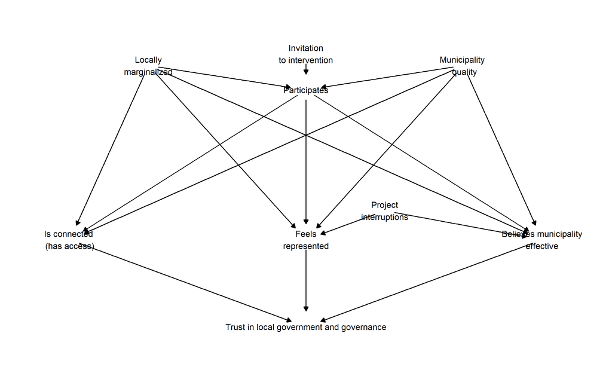

Back to working graph

## All arrows

Interview evidence on each arrow. Left column: attributed difference. Right column: that arrow negated.

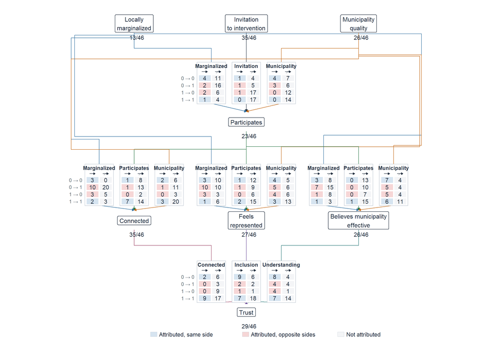

Back to raw scores · Quotes

## Parent-effect XY

Interview parent-effect means on the horizontal axis. Survey on the vertical axis.

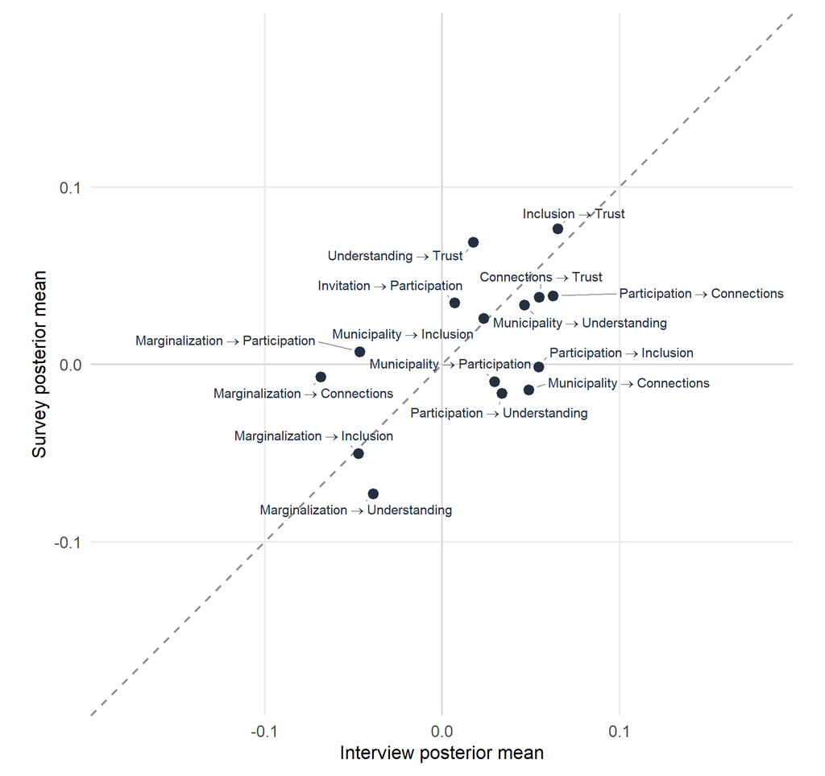

Back to interview DAG · Numbers

## Parent-effect numbers

| Edge | Interviews | Survey |
| --- | --- | --- |
| Invitation → Participation | 0.007 | 0.035 |
| Marginalization → Participation | -0.046 | 0.007 |
| Municipality → Participation | 0.030 | -0.010 |
| Marginalization → Connections | -0.068 | -0.007 |
| Municipality → Connections | 0.049 | -0.014 |
| Participation → Connections | 0.062 | 0.039 |
| Marginalization → Inclusion | -0.047 | -0.050 |
| Municipality → Inclusion | 0.023 | 0.026 |
| Participation → Inclusion | 0.054 | -0.001 |
| Marginalization → Understanding | -0.039 | -0.073 |
| Municipality → Understanding | 0.046 | 0.034 |
| Participation → Understanding | 0.034 | -0.016 |
| Connections → Trust | 0.055 | 0.038 |
| Inclusion → Trust | 0.065 | 0.076 |
| Understanding → Trust | 0.017 | 0.069 |

Back to XY

## 4-by-2 versus the query

The Invitation–Participation 4-by-2 is weakly negative at cutoff 0.75. The parent-effect query on that edge is weakly positive (0.007).

A crossed-out cell pins the realized (marginalization, municipality) background only. Leftover types that are flat there can still move participation on the other backgrounds. The query averages over all four backgrounds.

Factual scores and the Dirichlet update cut at 0.5. The displayed 4-by-2 uses 0.75. Hard four-type counts then diverge: 1 beneficial type at 0.75, 5 at 0.5.

Back to raw scores · Back to questions

## Unrestricted type count

|  | Node | Parents | Restricted types |
| --- | --- | --- | --- |
| Invitation | Invitation | 0 | 2 |
| Marginalization | Marginalization | 0 | 2 |
| Municipality | Municipality | 0 | 2 |
| Participation | Participation | 3 | 104 |
| Connections | Connections | 3 | 104 |
| Inclusion | Inclusion | 3 | 104 |
| Understanding | Understanding | 3 | 104 |
| Trust | Trust | 3 | 104 |

Unrestricted binary types: $2^{2^k}$ per node. Product across nodes: 8,796,093,022,208 ($2^{43}$).

The restriction (no sign change across backgrounds) is what makes the working model queryable. It is still a simplification: no unobserved confounding, and at most three parents per child.

Back to types

## Share rows

| Estimand | Priors | Interviews | Survey | Mixed |
| --- | --- | --- | --- | --- |
| Estimated share for whom the inclusion-only nested contrast is positive | 0.024 (0.003) | 0.021 (0.002) | 0.024 (0.001) | 0.024 (0.001) |
| Estimated share for whom the understanding-only nested contrast is positive | 0.024 (0.003) | 0.020 (0.002) | 0.025 (0.001) | 0.024 (0.001) |
| Estimated share for whom the connections-only nested contrast is positive | 0.024 (0.003) | 0.020 (0.002) | 0.024 (0.001) | 0.024 (0.001) |

Back to queries · Validation

## Node means

Raw survey means of DAG nodes by assignment. Difference is treated minus control. These are descriptive, not query estimates.

| Node | Treated | Control | Difference | SE | N |
| --- | --- | --- | --- | --- | --- |
| Invitation to intervention | 1.000 | 0.000 | 1.000 | 0.000 | 627 |
| Locally marginalized | 0.182 | 0.241 | -0.060 | 0.033 | 619 |
| Municipality quality | 0.545 | 0.517 | 0.028 | 0.040 | 619 |
| Project interruptions | — | — | — | — | — |
| Participates | 0.474 | 0.275 | 0.199 | 0.038 | 627 |
| Is connected (has access) | 0.528 | 0.510 | 0.018 | 0.044 | 525 |
| Feels represented | 0.816 | 0.784 | 0.032 | 0.032 | 617 |
| Believes municipality effective | 0.851 | 0.899 | -0.048 | 0.026 | 627 |
| Trust in local government | 0.578 | 0.581 | -0.003 | 0.040 | 627 |

Back to working graph